# Multivariate exploration and visualisation

Daniel Meloncelli

2023-12-01

The following code is based on the learning material developed by Drs Pavel Krivitsky and Spiridon Penev as part of the UNSW ZZSC5855 Multivariate Analysis course. The following example demonstrates basic multivariate summary statistics and graphics.

## Load the libraries

```r
library(magrittr) # pipe operator
library(purrr)
```

## Load the data

The “Iris” dataset is built into the `stats` package, so it can acquired via the `data()` function.

```r
data(iris)
```

## Basic data summaries

The summary() function can be used to obtain basic 5-number summaries.

```r
summary(iris)
```

```
  Sepal.Length    Sepal.Width     Petal.Length    Petal.Width
 Min.   :4.300   Min.   :2.000   Min.   :1.000   Min.   :0.100
 1st Qu.:5.100   1st Qu.:2.800   1st Qu.:1.600   1st Qu.:0.300
 Median :5.800   Median :3.000   Median :4.350   Median :1.300
 Mean   :5.843   Mean   :3.057   Mean   :3.758   Mean   :1.199
 3rd Qu.:6.400   3rd Qu.:3.300   3rd Qu.:5.100   3rd Qu.:1.800
 Max.   :7.900   Max.   :4.400   Max.   :6.900   Max.   :2.500
       Species
 setosa    :50
 versicolor:50
 virginica :50
```

The `apply` function can be used to obtain univariate summaries for each variable.

- Column means

```r
colMeans(iris[,-5])
```

```
Sepal.Length  Sepal.Width Petal.Length  Petal.Width
    5.843333     3.057333     3.758000     1.199333
```

- Column standard deviations

```r
apply(iris[-5], 2, sd)
```

```
Sepal.Length  Sepal.Width Petal.Length  Petal.Width
   0.8280661    0.4358663    1.7652982    0.7622377
```

- Column 95th percentiles

```r
apply(iris[-5], 2, quantile, 0.95)
```

```
Sepal.Length  Sepal.Width Petal.Length  Petal.Width
       7.255        3.800        6.100        2.300
```

- Variance-covariance matrix

```r
cov(iris[,-5])
```

```
             Sepal.Length Sepal.Width Petal.Length Petal.Width
Sepal.Length    0.6856935  -0.0424340    1.2743154   0.5162707
Sepal.Width    -0.0424340   0.1899794   -0.3296564  -0.1216394
Petal.Length    1.2743154  -0.3296564    3.1162779   1.2956094
Petal.Width     0.5162707  -0.1216394    1.2956094   0.5810063
```

- Correlation matrix

```r
cor(iris[,-5])
```

```
             Sepal.Length Sepal.Width Petal.Length Petal.Width
Sepal.Length    1.0000000  -0.1175698    0.8717538   0.8179411
Sepal.Width    -0.1175698   1.0000000   -0.4284401  -0.3661259
Petal.Length    0.8717538  -0.4284401    1.0000000   0.9628654
Petal.Width     0.8179411  -0.3661259    0.9628654   1.0000000
```

We can also apply to subgroups. For this, we use the “pipe” operator `%>%` from package `magrittr`, which evaluates each function in turn, passing its results as the first argument of the next one (or `.`). We also use `map` function from the `purrr` package.

```r
iris %>% # Start with dataset iris
  split(iris$Species) %>% # Split it according to its species column
  map(~.[-5]) %>% # For each species, throw away the last column (Species)
  map(cov)
```

```
$setosa
             Sepal.Length Sepal.Width Petal.Length Petal.Width
Sepal.Length   0.12424898 0.099216327  0.016355102 0.010330612
Sepal.Width    0.09921633 0.143689796  0.011697959 0.009297959
Petal.Length   0.01635510 0.011697959  0.030159184 0.006069388
Petal.Width    0.01033061 0.009297959  0.006069388 0.011106122

$versicolor
             Sepal.Length Sepal.Width Petal.Length Petal.Width
Sepal.Length   0.26643265  0.08518367   0.18289796  0.05577959
Sepal.Width    0.08518367  0.09846939   0.08265306  0.04120408
Petal.Length   0.18289796  0.08265306   0.22081633  0.07310204
Petal.Width    0.05577959  0.04120408   0.07310204  0.03910612

$virginica
             Sepal.Length Sepal.Width Petal.Length Petal.Width
Sepal.Length   0.40434286  0.09376327   0.30328980  0.04909388
Sepal.Width    0.09376327  0.10400408   0.07137959  0.04762857
Petal.Length   0.30328980  0.07137959   0.30458776  0.04882449
Petal.Width    0.04909388  0.04762857   0.04882449  0.07543265
```

## Visualisation

The most common visualisation for multivariate data is a pairwise plot: plot every variable against every other variable. A function that does it well—and automatically takes care of categorical variables—is `GGally`’s `ggpairs` function.

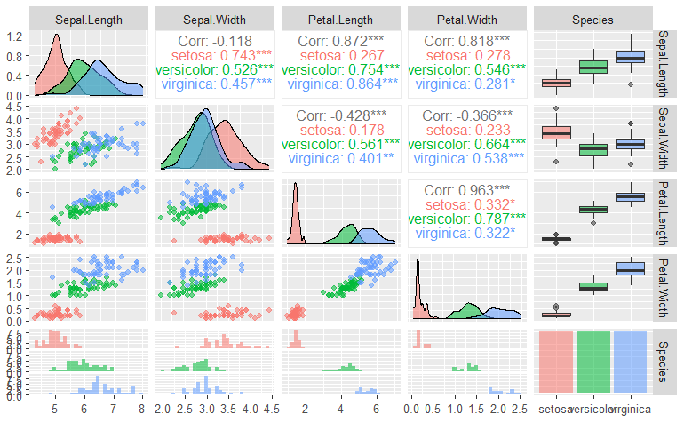

```r
library(GGally)
ggpairs(iris, aes(colour=Species, alpha = 0.7))
```

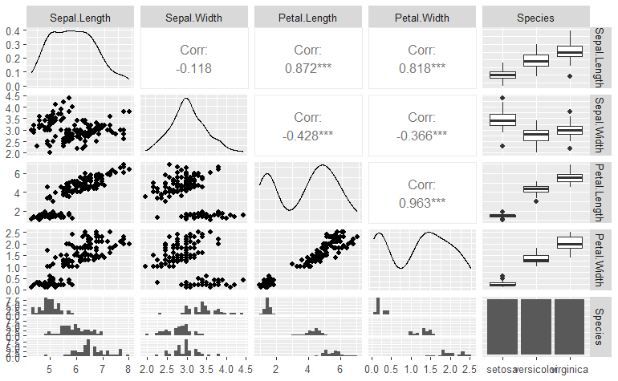

```r
ggpairs(iris)
```